# CHDH SNA INTRO

[Johan Koskinen](https://https://www.su.se/english/profiles/kosk-1.615440)

2026-03-15

# Overview

- Adjacency matrix, basic manipulation
- Network non-parametric approaches
- Ego-nets
- Network regression

# Adjacency matrix

## Basic definitions

For a set of nodes $V=\{1,\ldots,n\}$ we define a set of ties as being un-ordered pairs of nodes, $\{i,j\} \in \{i,j\in V : i\neq j\}$. We can denote the set of all undordered pairs ${V}\choose{2}$, meaning that the ties or edges are two-element subsets of $V$, and the set of ties $E \subseteq {{V}\choose{2}}$.

## Adjacency matrix

For all $\{i,j\} \in {{V}\choose{2}}$, we define the tie-variables $x_{ij}$ as being indicators
$$\begin{equation*}
x_{ij}= \left\{
\begin{array}{lr}
1,&\text{if there is an edge between } i \text{ and } j\\
0,&\text{else}
\end{array}
\right.
\end{equation*}$$

We collect these in an $n \times n$ **adjacency matrix**
$$X = \begin{bmatrix}
x_{11} & x_{12} & x_{13} & \cdots & x_{1n}\\
x_{21} & x_{22} & x_{23} & \cdots & x_{2n}\\
x_{31} & x_{32} & x_{33} & \cdots & x_{3n}\\
\vdots & \vdots & \vdots & \ddots & \vdots \\
x_{n1} & x_{n2} & x_{n3} & \cdots & x_{2n}\\
\end{bmatrix}$$

## Objectives

This is an introduction to social networks using built-in functions in R and the packages sna and network. We will learn the

- basic features of the adjacency matrix represented as a matrix object,
  - calculate the degrees of the nodes, and
  - calculate some fundamental descriptives of the network.
- We will then translate the network
  - from a matrix object to a network object in order to
  - plot the sociogram.

For full details of the packages, see https://cran.r-project.org/web/packages/sna/sna.pdf and https://cran.r-project.org/web/packages/network/network.pdf. For accessile general R-help see https://www.statmethods.net/ and for any kind of errors use https://google.com.

This introduction is deliberately writen in **inelegant R**, using as basic functions as possible. Many packages offer sleeker and more userfriendly network routines, such as ‘igraph’. In particular, I would like to recomend the packages of David Schooch http://mr.schochastics.net/ for accessible and elegant network analysis in R. In general, basic plots in R (described in https://www.statmethods.net/graphs/index.html) are functional but more advanced and better looking plots can be acchieved through ‘ggplot’.

For basic concepts in network analysis see G. Robins (2015) and Borgatti, Everett, and Johnson (2018). There is also a handy online bool http://faculty.ucr.edu/~hanneman/nettext/ (Hanneman and Riddle 2005).

## Build your own network

To use sna(Butts 2016) and network (Butts 2015) for the first time (*uncomment the install commmands*), install the packages

```r
# install.packages("sna")
# install.packages("network")
```

Once packages are installed, load them

```r
library("sna")
library("network")
```

### The Matrix

Create an empty **adjacency** matrix for n = 5 nodes

```r
n <- 5
ADJ <- matrix(0,n,n) # create a matrix with n rows and n columns and all values 0
```

Add ties $1 \rightarrow 2$, $1 \rightarrow 3$, $2 \rightarrow 3$, $3 \rightarrow 4$, and , $4 \rightarrow 5$

```r
ADJ[1,2] <- 1
ADJ[1,3] <- 1
ADJ[2,3] <- 1
ADJ[3,4] <- 1
ADJ[4,5] <- 1
ADJ
```

To make the network **undirected**, add the ties $2 \rightarrow 1$, $3 \rightarrow 1$, $3 \rightarrow 2$, $4 \rightarrow 3$, and $5 \rightarrow 4$

```r
ADJ[2,1] <- 1
ADJ[3,1] <- 1
ADJ[3,2] <- 1
ADJ[4,3] <- 1
ADJ[5,4] <- 1
ADJ
```

```
##      [,1] [,2] [,3] [,4] [,5]
## [1,]    0    1    1    0    0
## [2,]    1    0    1    0    0
## [3,]    1    1    0    1    0
## [4,]    0    0    1    0    1
## [5,]    0    0    0    1    0
```

#### Cells in the adjacency matrix and tie-variables

In general the cell ADJ[i,j] corresponds to the tie-variable $X_{i,j}$. Here $x_{1,2}=1$

```r
ADJ[1,2]
```

but, for example, $x_{1,4}=0$

```r
ADJ[1,4]
```

The ties of node $i=1$ is the $i$’th row

```r
ADJ[1,]
```

#### Density

The adjcenacy matrix has

```r
dim(ADJ)
```

rows and columns. This means that there are $n \times n$ cells in the adjacency matrix.

```r
dim(ADJ)[1]*dim(ADJ)[2]
length(ADJ)
```

The $n$ diagonal elements $x_{11},x_{22},\ldots,x_{nn}$ are zero by definition, which means that there are $n \times n - n = n(n-1)$ variables that can be non-zero, here

```r
dim(ADJ)[1]*dim(ADJ)[2] - n
```

> **Density**: How many variables are equal to 1 out of the total posible?

The total number of ones
$$L =
\sum_{i,j,i\neq
j}x_{ij}=x_{12}+\cdots+x_{1n}+x_{21}+\cdots+x_{(n-1)n}$$
is simply a count of the number of non-zero entries

```r
sum(ADJ)
```

The density thus is

```r
sum(ADJ)/(n*(n-1))
```

and 50% of possible ties are present in the network.

#### Degree

> How many ties does a node have?

The **degree** $d_i$ of a node $i$ is defined as the sum $d_i=\sum_{j}x_{i,j}=x_{i,2}+x_{i,2}+\cdots + x_{i,n}$. The degree of node $i=1$ is thus

```r
sum(ADJ[1,])
```

and the degree of node $i=2$ is

```r
sum(ADJ[2,])
```

#### Degree distribution

Calculate the *column sum* of the adjacency matrix to get the vector of degrees (note the capital S)

```r
colSums(ADJ)
```

The **degree distribution** is the table of frequencies of degrees

```r
table( colSums(ADJ) )
```

You can chart the degree distribution with a bar chart

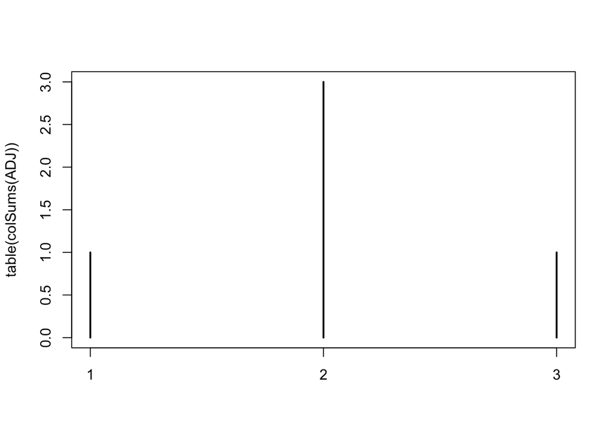

```r
plot( table( colSums(ADJ) ))
```

> You can use standard R-routines to explore the adjacency matrix

For example finding what node (-s) have, say, degree 3

```r
which(colSums(ADJ)==3)
```

Or subsetting the adjacency matrix to look only at nodes with degree 2 or greater

```r
use <- which(colSums(ADJ)>=2) # for each row there will be a logical TRUE or FALSE
ADJ[use,use]
```

#### Fun Fact: Linear algebra

Most network metrics can be calculated using linear algebra. For example, if $X_{i,j}$ in $X$ tell you if $i$ and $j$ are directly connected, element $(XX)_{i,j}$ of the matrix product $XX$, tells you how many paths $i \rightarrow k \rightarrow j$ there are

```r
ADJ %*% ADJ
```

Element $(XXX)_{i,j}$ of the matrix product $XXX$, tells you how many paths $i \rightarrow k \rightarrow h \rightarrow j$ there are

```r
ADJ %*% ADJ %*% ADJ
```

### Network object

Plotting the matrix object ADJ is not meaningful because R does not know that this is an adjacency matrix. To interpret ADJ as a network, translate the adjacency matrix to a network object

```r
net <- as.network(ADJ, directed = FALSE)
```

NB: in the network package you use directed=FALSE in lieu of setting mode equal to graph.

The new object net is an object of type

```r
class(net)
```

While printing ADJ to screen just gives you the matrix, priniting net gives you a summary of the network

```r
net
```

#### Plot sociogram

When plotting a network object, R knows that you want to plot the **sociogram**

```r
plot( net )
```

For various plotting option see ?plot.network. For example, set node-size to degree, include labels, and set different colours

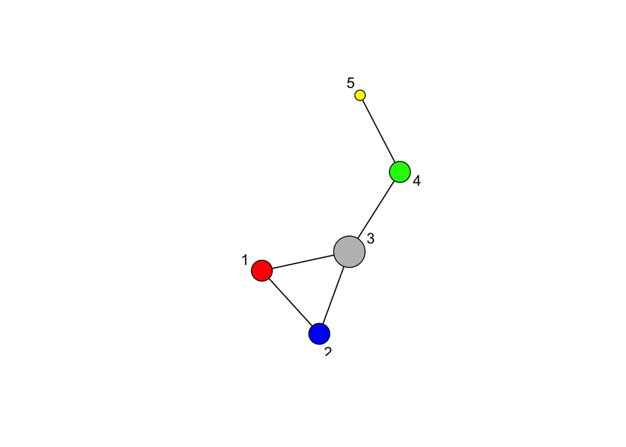

```r
plot( net , # the network object
      vertex.cex = degree(net) , # how should nodes (vertices) be scaled
      displaylabels =  TRUE, # display the labels of vertices
      vertex.col = c('red','blue','grey','green','yellow'))
```

Note that degree(net) is a built-in function in network for calculating the degrees of the nodes. The next step will explore more of these functions.

## Network position

Continue with the network that we constructed previously in Minimal Intro.

Recall, basic properties of this network are

```r
net
```

```
##  Network attributes:
##   vertices = 5
##   directed = FALSE
##   hyper = FALSE
##   loops = FALSE
##   multiple = FALSE
##   bipartite = FALSE
##   total edges= 5
##     missing edges= 0
##     non-missing edges= 5
##
##  Vertex attribute names:
##     vertex.names
##
## No edge attributes
```

### Degree centrality

> What nodes have more ties?

```r
degree( net )
```

This is vector with the degree centrality for each node in the network. Degree centrality is also called Freeman degree centrality (Freeman 1978).

### Betweeness centrality

Betweeness is related to connectivity and flow in a network (Freeman 1978; Borgatti and Everett 2006). This measure requires that you know the network structure of the entire network.

```r
betweenness( net , gmode ='graph' )
```

Node 3 is on the *shortest path* between 4 pairs of nodes:

| Start node | Step 2 | Step 3 | Step 4 |
| --- | --- | --- | --- |
| 1 | **3** | 4 |  |
| 1 | **3** | 4 | 5 |
| 2 | **3** | 4 |  |
| 2 | **3** | 4 | 5 |

> These nodes will only be able to ‘communicate’ via 3

### Brokers

A cutpoint is a node that when removed results in the network having more components. In simpler terms, a cutpoint is a node that connects otherwise dissconnected nodes

```r
cutpoints( net , mode = "graph")
```

```
## [1] 3 4
```

The extent to which nodes broker between other nodes has been the fucus of a large part of Ron Burt’s career. He proposes some elaborations for measuring bokerness in Burt (2009) called *constraint* and *effective size*. These are *local* measures that do not, as opposed to cutpoints and betweeness, require that you know the network structure of the entire network.

### Triad census

The triad census tabulates different types of triangles or triples (J. A. Davis 1967; Holland and Leinhardt 1972)

| 0 edges | 1 edge | 2 edges | 3 edges |
| --- | --- | --- | --- |
| $\sharp$ tripels | $\sharp$ tripels | $\sharp$ tripels | $\sharp$ tripels |

```r
triad.census( net , mode = "graph")
```

```
##      0 1 2 3
## [1,] 0 6 3 1
```

There are 6 triples, with one tie. For example the *subgraph* consisting of nodes 1,4 , and 5.

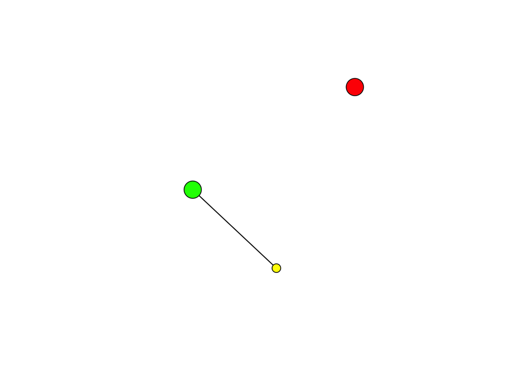

```r
plot(as.network( ADJ[c(1,4,5),c(1,4,5)] , directed = FALSE),
     vertex.cex = degree(net)[c(1,4,5)],
     vertex.col = c('red','blue','grey','green','yellow')[c(1,4,5)])
```

**Open triad**: There are 3 triples, with two ties. For example the *subgraph* consisting of nodes 3, 4 , and 5.

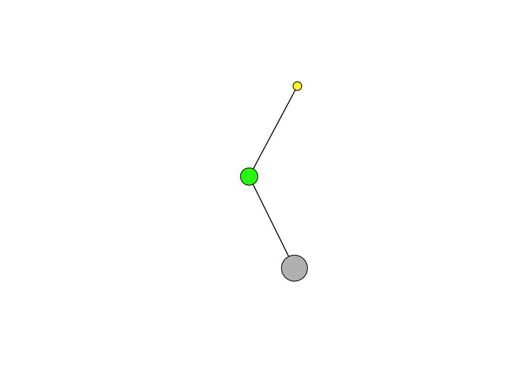

```r
plot(as.network( ADJ[c(3,4,5),c(3,4,5)] , directed = FALSE),
     vertex.cex = degree(net)[c(3,4,5)],
     vertex.col = c('red','blue','grey','green','yellow')[c(3,4,5)])
```

**Closed triad**: There is 1 triple, with three ties. For example the *subgraph* consisting of nodes 1, 2 , and 3.

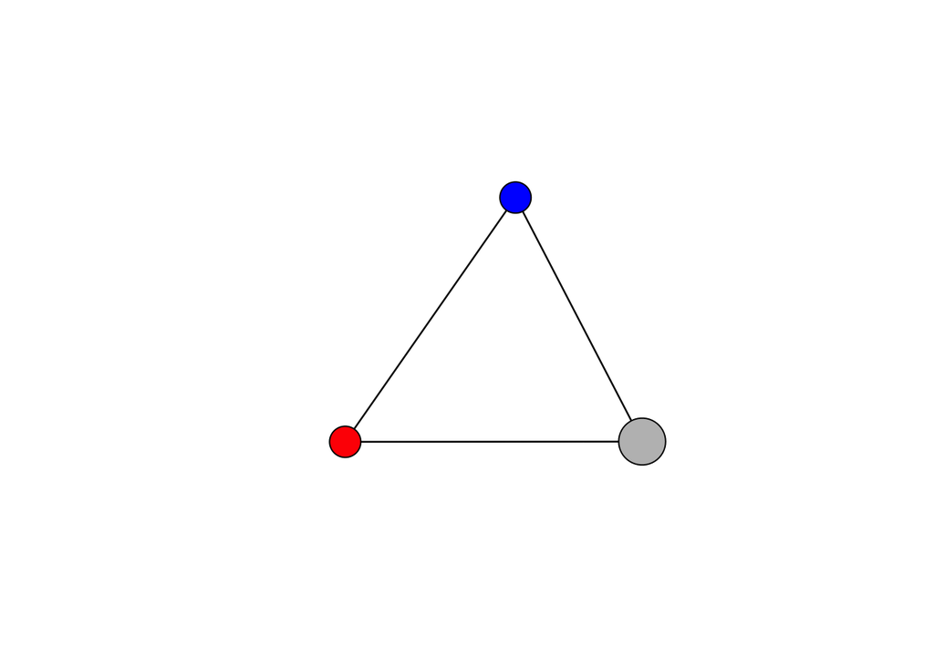

```r
plot(as.network( ADJ[c(1,2,3),c(1,2,3)] , directed = FALSE ),
     vertex.cex = degree(net)[c(1,2,3)],
     vertex.col = c('red','blue','grey','green','yellow')[c(1,2,3)] )
```

### Cliques

A $k$-clique is a maximally connected subgraph. This means that a $k$-clique is a network with $k$ nodes that are all connected to each other. In net nodes 5 and 4 consitute a 2-clique and nodes 1, 2, and 3 constitute a 3-clique. Like the triad census, we can calulate a clique census for a graph

```r
cc <- clique.census( net , mode = "graph")
```

The object cc is of class

```r
class(cc)
```

The list has the following objects

```r
names(cc)
```

The object clique.count lists the membership of nodes in cliques

```r
cc$clique.count
```

A list of lists of cliques and their members is provided in

```r
cc$cliques
```

Note that subgraphs of cliques are not listed. For example, the 2-cliques with nodes 1 and 2 is not listed as both are part of the larger 3-clique.

## Position directed

This is an introduction to anylisng **directed** networks in R using the packages sna and network. We will revisit the *adjacency matrix* and the notion of *tie variables* for directed networks.

We will learn the basic

- differences between in- and out-degree
- definitions of the basic subgraphs
  - dyads
  - triads

We will use a dataset of 73 high school pupils collected by James Coleman (1964) that comes with the package `sna.

For full details of the packages, see https://cran.r-project.org/web/packages/sna/sna.pdf and https://cran.r-project.org/web/packages/network/network.pdf.

The background of, and description, of the dataset is provided in the helpfile

```r
?coleman
```

Now load the network

```r
data(coleman)
```

### The adjacency matrix

> What do I have in my workspace and what did I load?

The function data() loaded something. Use the general purpose command ls() to list what is in your workspace

```r
ls()
```

This is not one adjacency matrix but

```r
class(coleman)
```

As described in the help file this is an array with 2 $\times$ adjacency matrices of dimensions $73 \times 73$

```r
dim(coleman)
```

The individual slices are matrices

```r
class(coleman[1,,])
class(coleman[2,,])
```

You can print coleman[1,,] and coleman[2,,] to screen to view the adjacency matrices (but that will just be a lot of ones and zeros, in particular $2 \times 73 \times 73$ ones and zeros). You can visualise the adjacency matrices in these matrix plots

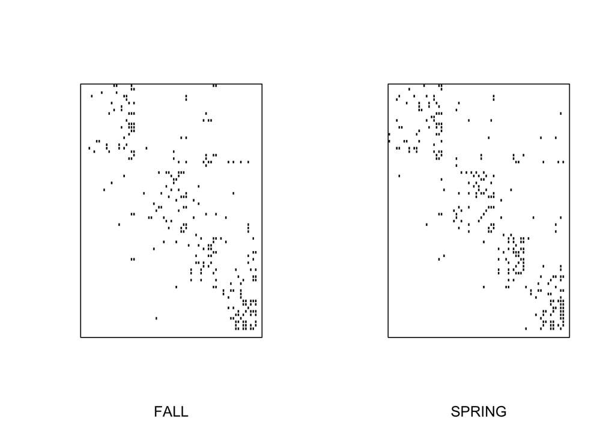

```r
par( mfrow = c(1,2))
plot.sociomatrix( coleman[1,,] , drawlab=FALSE , drawlines = FALSE, xlab = 'FALL')
plot.sociomatrix( coleman[2,,] , drawlab=FALSE , drawlines = FALSE, xlab = 'SPRING')
```

In the adjacency matrix, rows record the ties *sent*, and columns record the ties *received*. Student 1 has the out-tie variables $x_{1,2},x_{1,3},\ldots,x_{1,n}$

```r
 coleman[1,1,]
```

For example, that coleman[1,1,14] is 1 means that student 1 has a tie to student 14, and that coleman[1,1,2] is 0 means that student 1 does not have a tie to student 2.

#### Outdegree

Taking the sum of the outties

```r
 sum(coleman[1,1,])
```

gives us student 1’s **outdegree**, $d_i^o= \sum_{j,j\neq i}x_{i,j}$.

To get the outdegree of all pupils, sum across columns for all rows

```r
 rowSums(coleman[1,,])
```

And, like for un-directed networks, we can chart the the degree distribution

```r
 plot( table (rowSums(coleman[1,,]) ))
```

#### Indegree

The ties a student has received is the column of that particular student. Student 1 has received the tie variables $x_{2,1},x_{3,1},\ldots,x_{n,1}$

```r
 coleman[1,,1]
```

For example, that coleman[1,14,1] is 0 means that student 1 has not received a tie *from* student 14.

To get the **indegree** of all pupils sum across rows for all columns

```r
 colSums(coleman[1,,])
```

And, like for un-directed networks, we can chart the the indegree distribution

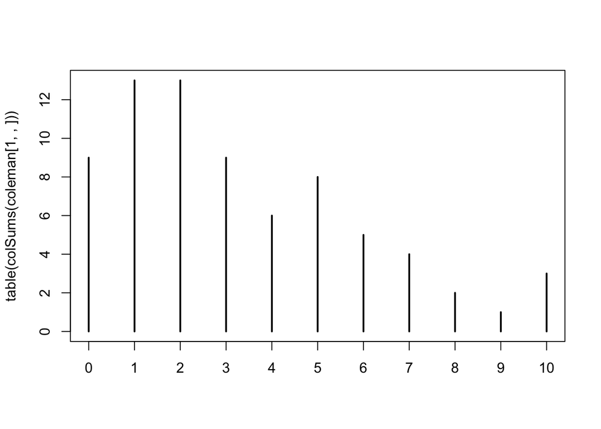

```r
 plot( table (colSums(coleman[1,,]) ))
```

> The number of ties sent and received are not the same!

For example, student 1 has nominated 5 other people but student 1 has not been nominated back at all. Plotting the outdegrees against the indegrees

```r
 plot( jitter(rowSums(coleman[1,,]) ) , jitter( colSums(coleman[1,,]) ) )
```

reveal that some send more than they receive, and some send fewer than they receive.

One reason for this is that some pairs are asymmetric and other pairs are symmetric in their choices (there are of course other possible explanations Igarashi and Koskinen 2020)

### Dyads and reciprocity

A **dyad** is a pair of nodes and their ties $(X_{i,j}X_{j,i})$ to each other. To investigate whether pairs are symmetric or asymmetric, consider e.g. that 1 nominated 14 but 14 did not nominate 1 back - this pair is asymmetric.

```r
 coleman[1,1,14]
 coleman[1,14,1]
```

The dyad 19 and 4

```r
 coleman[1,4,19]
 coleman[1,19,4]
```

is symmetric, or **reciprocal** - we call this a **mutual dyad**.

In general we can distinguish between dyads that are *Mutual*, *Assymetric*, and *Null* (Holland and Leinhardt 1972):

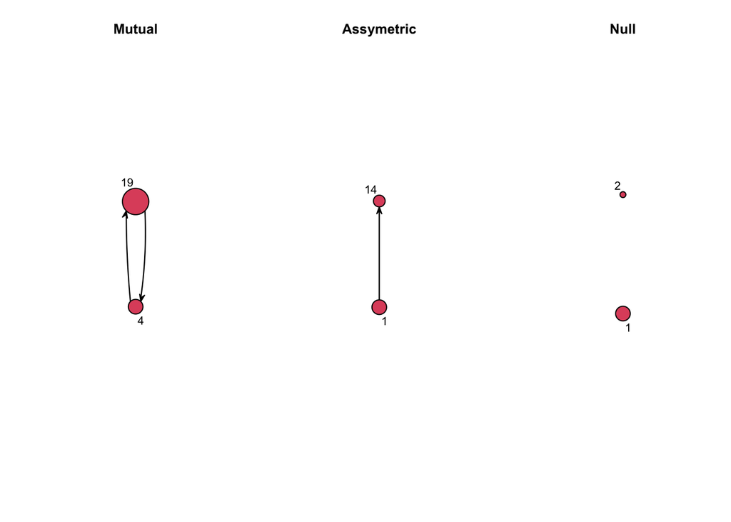

```r
par ( mfrow = c(1,3))
plot( as.network(coleman[1,c(4,19),c(4,19)] ),main='Mutual' ,label = c(4,19), usecurve = TRUE, edge.curv = 0.01, arrowhead.cex = 2.5, vertex.cex = degree(coleman[1,,])[c(4,19)] )
plot( as.network(coleman[1,c(1,14),c(1,14)] ),main='Assymetric' ,label = c(1,14), arrowhead.cex = 2.5, vertex.cex = degree(coleman[1,,])[c(1,14)] )
plot( as.network(coleman[1,c(1,2),c(1,2)] ),main='Null' ,label = c(1,2) , vertex.cex = degree(coleman[1,,])[c(1,2)] )
```

#### Fun Fact: Linear algebra

Recall that the inner product of a matrix $X$ with itself $X$ has entries $(XX)_{i,j}=\sum_{k}X_{i,k} X_{ k,j }$. Consequently, $\mathrm{tr}(XX)$ gives you twice the number of reciprocated dyads. There is no standard command for trace in R, but you can take the sum() of the diagonal diag() of the matrix product, e.g. for adjacency matrix A, sum( diag( A %*% A )). The standard product* in R is the dot product $X \odot X^{\top}$ where $(X \odot X^{\top})_{i,j}=X_{i,j} X_{ i,j }$. Consequently for adjacency matrix A, A * t(A) is the matrix of reciprochated ties.

### Dyad census

The **dyad census** tabulates the number of dyads that are Mutual, Assymetric, and Null

```r
 dyad.census(coleman[1,,])
```

```
##      Mut Asym Null
## [1,]  62  119 2447
```

#### Fun Fact: census is complete enumeration of dyads

Note that in the Coleman example, the total number of M, A, and N dyads sum up to

```r
 62 + 119 +  2447
```

which is exactly equal to $n(n-1)/2=73\times72/2=2628$ - this is the total number on (un-ordered) pairs, the number of cells in the upper diagonal of the adjacency matrix.

### Triads

For triplets in directed networks, there many different kinds. For *open triads*, we could for example consider the three different types you can achieve with 0 Mutual dyads, 2 Assymetric dyads, and 1 Null dyad.

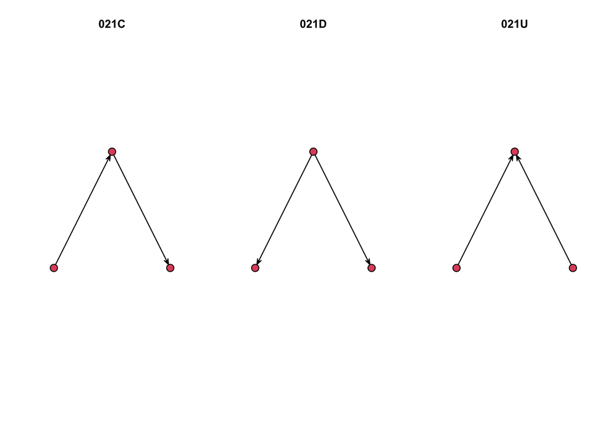

```r
par( mfrow = c(1,3))
plot( as.network( matrix(c(0,1,0,0,0,1,0,0,0),3,3 ,byrow=TRUE) ), coord = matrix(c(0,0,5,10,10,0) ,3,2,byrow=TRUE) ,arrowhead.cex = 2.5, vertex.cex =3 , jitter = FALSE, main='021C')
plot( as.network( matrix(c(0,1,0,0,0,0,0,1,0),3,3 ) ), coord = matrix(c(0,0,5,10,10,0) ,3,2,byrow=TRUE) ,arrowhead.cex = 2.5, vertex.cex =3 , jitter = FALSE, main='021D')
plot( as.network( matrix(c(0,0,0,1,0,1,0,0,0),3,3 ) ), coord = matrix(c(0,0,5,10,10,0) ,3,2,byrow=TRUE) ,arrowhead.cex = 2.5, vertex.cex =3 , jitter = FALSE,  main='021U')
```

The triples are labeled by the number of Mutual, Assymetric, and Null dyads - the so-called MAN labeling scheme. Here, the ‘C’, ‘D’, and ‘U’ distinguish between ‘Cyclic’, ‘Down’, and ‘Up’.

For closed triands consider the Transitive (‘T’), Cyclic (‘C’), and complete closed triads

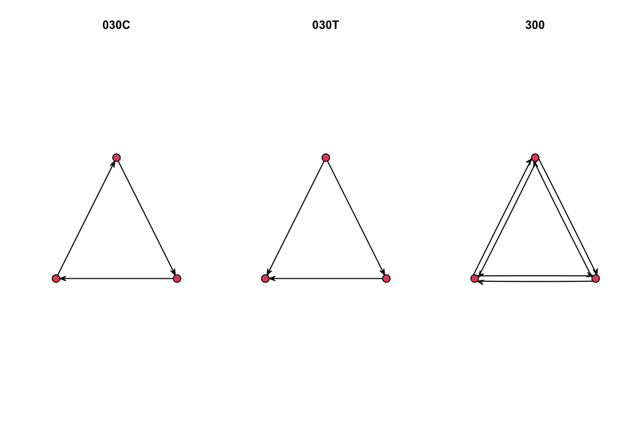

```r
par( mfrow = c(1,3))
plot( as.network( matrix(c(0,1,0,0,0,1,1,0,0),3,3 ,byrow=TRUE) ), coord = matrix(c(0,0,5,10,10,0) ,3,2,byrow=TRUE) ,arrowhead.cex = 2.5, vertex.cex =3 , jitter = FALSE, main='030C')
plot( as.network( matrix(c(0,1,1,0,0,0,0,1,0),3,3 ) ,byrow=TRUE), coord = matrix(c(0,0,5,10,10,0) ,3,2,byrow=TRUE) ,arrowhead.cex = 2.5, vertex.cex =3 , jitter = FALSE, main='030T')
plot( as.network( matrix(c(0,1,1,1,0,1,1,1,0),3,3 )  ,byrow=TRUE), coord = matrix(c(0,0,5,10,10,0) ,3,2,byrow=TRUE) ,arrowhead.cex = 2.5, vertex.cex =3 , jitter = FALSE,  main='300', usecurve = TRUE, edge.curv = 0.01)
```

When considering the potential interpretation of these closed triads, imagine scenarios where ties reflect ‘liking’, ‘look up to’, ‘give orders’, ‘passing on information’, and how these structures would be reflected in status, chain of command, access to information, etc.

### Triad census

In total there are 16 types of triangles, all of which are labelled using the MAN labeling scheme (Holland and Leinhardt 1972). For the Coleman data, we calulate the **triad census** as

```r
 triad.census(coleman[1,,])
```

```
##        003  012  102 021D 021U 021C 111D 111U 030T 030C 201 120D 120U 120C 210
## [1,] 50171 7384 3957   64  121  128  139   70   23    1  20   43   10    9  34
##      300
## [1,]  22
```

#### Fun Fact: census is complete enumeration of triads

Note that in the Coleman example, the total number triads

```r
sum(triad.census(coleman[1,,]))
```

which is exactly equal to
$$\binom{n}{3}=
\frac{n(n-1)(n-1)}{(3\times 2)}=73\times72\times71/6=62196$$
- this is the total number on (un-ordered) triplets, the number of ways in which you can chose 3 element subsets out of a 73 element set.

### Plotting the network

Plotting the sociogram of the network does not differ from the undirected case, with the exception that the ties are now represented by arrows.

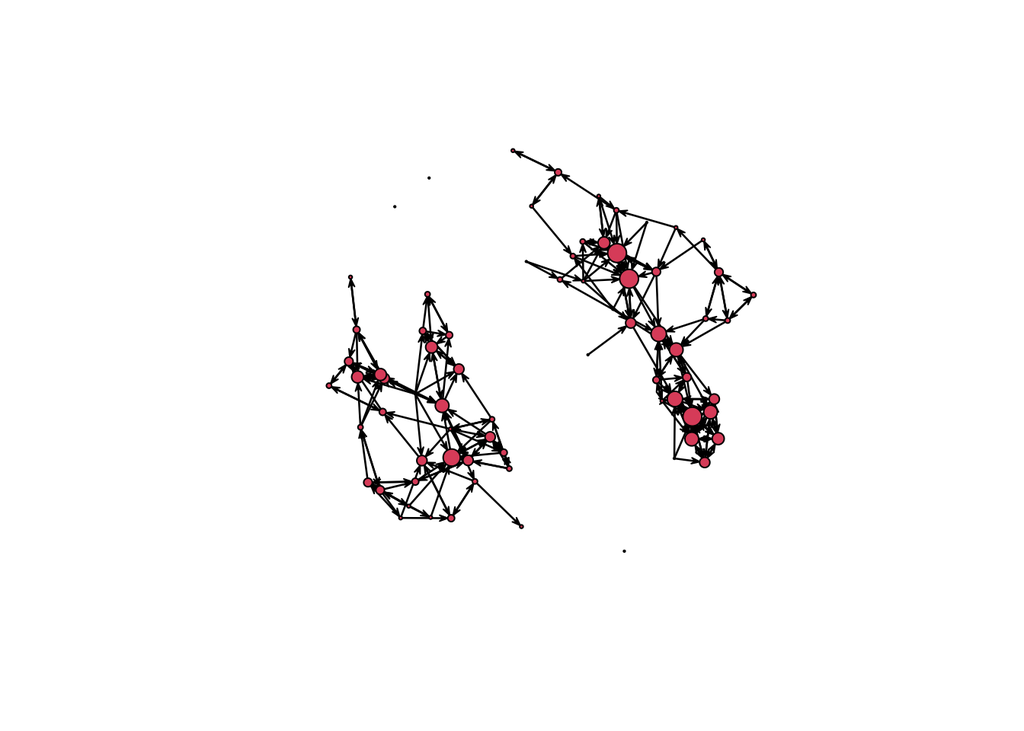

```r
plot( as.network( coleman[1,,] , directed= TRUE), # the network object
      vertex.cex = degree(coleman[1,,], cmode = 'indegree')/5 + .2 )
```

The size of a node here is set proportional to the indegree centrality.

> There are two large ‘clusters’ of nodes that are connected within but not between - these are two **components**

# Non-parametric

We are going to use real networks to investigate how much these (undirected) networks differ from random networks. Analogously, we might ask what features of the networks are not guided by chance.

Make sure that you have loaded the required libraries but also load `ergm()`

```r
library("ergm")
```

## Reading in data

Here we are going to use two networks. If you want to try this out on other data, you will find how to read in the data and format it in the `Data-Formatting-2025.Rmd` vignette.

### Padgett business

The adjacency matrix for the Padgett and Ansell (1993) business network is stored as a regular text file `PADGB.txt` on GitHub

[figure not shown]

Files on GitHub repos

Read this in using `read.table`

```r
padgettbus <- as.matrix(read.table("https://raw.githubusercontent.com/johankoskinen/CHDH-SNA/main/data/PADGB.txt"))
# Look at the matrix - what does it look like
```

Format this as a `network` object

```r
padgbus.net <- as.network(padgettbus,# take the raw data
                          directed = FALSE )# make sure you tell network that this is undirected
```

### Some notation

We let the set of $n$ nodes be $V = \{1,\ldots,n \}$, and we define the symmetric adjacency matrix $X=(X_{ij})_{ij \in V^{(2)}}$, where the non-redundant pairs are $\mathcal{N} = { V \choose 2}$, with elements

$$X_{ij}= \left\{
\begin{array}{lr}
1,&\text{if there is a tie from } i \text{ to } j, i,j \in V\\
0,&\text{else}
\end{array}
\right. {\text{,}}$$

## Completely random graph

Assume that we independently for each pair, $\{i,j\}$, decided if the tie existed by tossing a fair coin. This means that, *independently* for all $\{i,j\} \in \mathcal{N}$
$$\Pr (X_{ij}=1) = 0.5$$
In sna, the function rgraph generates random graphs.

### Padgett’s business network

Generate a $n=16$ completely random graph and compare it to the Padgett and Ansell (1993) Florentine families business network

#### Generate random network

We will generate a network that only has $n$ in common with the Padgett data set.

```r
n <- dim(padgettbus)[1]
g <- rgraph(n,#size of the network
            m=1,# number of networks to generate
            tprob=0.5,# tie probability
            mode="graph") # undirected (graph) or directed (digraph)
g.net <- as.network(g,directed=FALSE)# 'sna' give you a matrix
gden( padgbus.net )# observed density
gden(g.net)# density
```

Now we can compare what a network would look like if ties were formed completely at random with our observed network.

#### Plot and compare

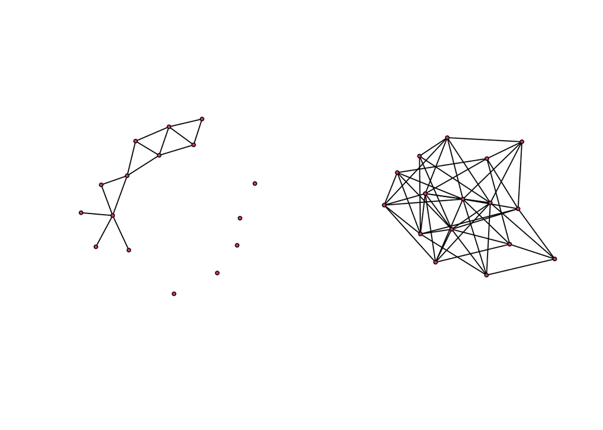

```r
par(mfrow=c(1,2))
plot(padgbus.net)
plot(g.net)
```

> Does it look more ‘random’ than the Padgett network?

This is only *one* random network, maybe it looks different by chance. Generate $m = 100$ networks

```r
n <- dim(padgettbus)[1]
g100 <- rgraph(n,#size of the network
            m=100,# number of networks to generate
            tprob=0.5,# tie probability
            mode="graph") # undirected (graph) or directed (digraph)
```

#### Calculate metrics

Any metric that we calculate for the *observed* network we can calculate for a *random* network

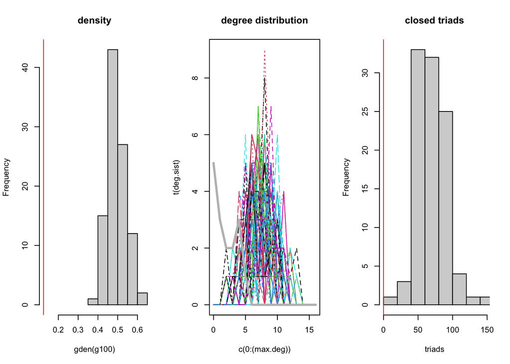

```r
max.deg <- 16 # just set the maximal degree to plot
par( mfrow  = c(1,3) )
hist( gden( g100) , # the density for each of the 100 random networks
      xlim=range( gden( g100 ),
                  gden( padgbus.net ) ) , main='density')
abline( v=gden( padgbus.net ),col='red' )# the observed density for reference

obs.degrees <-  degree(padgbus.net,cmode='indegree')# observed degrees
obs.degree <-  c(sum(obs.degrees==0),tabulate(obs.degrees, nbins=max.deg))# observed degree distribution
degrees <-degree(g100,g=c(1:100), cmode='indegree')# you can calculate the degree distributions for all graphs
deg.sist <- cbind( matrix( colSums(degrees==0),100,1),
                  t(apply(degrees,2,function(x) tabulate(x, nbins=max.deg) ) ) )# when tabulating we need to add the number of isolates
matplot(c(0:(max.deg)), t(deg.sist) ,
        type ='l',
        main='degree distribution' )
lines(c(0:(max.deg)),obs.degree ,col='grey',lwd=3)

triads <- triad.census( g100 , mode='graph')[,4]# CHANGE
T4 <- triad.census(padgbus.net)[4]# observed number of closed triangles
hist(triads ,
     xlim= range( triads , T4 ),
     main = 'closed triads')
abline( v=T4,col='red' )# the observed density for reference
```

Clearly, since the random networks are *too dense*, the degree distributions are also different from the observed network, with nodes on average having a higher degree. But

> despite how dense the networks are, there are too many triangles but is that because we have so many more ties???

#### Fixed density: implications

Will a random network with density $0.5$ resemble any networks?

> fixing the density at 0.5 irrespective of network size give unrealisically dense networks

## Density conditioned graph

If we do not get density right, we won’t get anything righ. We introduce a random graph that fixes the density.

### Definition

Let $L(x) = \sum_{i<j}x_{ij}$ be the number of edges in a graph. The number of graphs with exactly $k$ edges
$$\mathcal{X}_k= \{ x \in \mathcal{X} : L(x)=k \}$$
is given by ${ M \choose k}$, where $M= { n \choose 2}$, and consequently the conditional distribution
$$\Pr(X=x \mid L(x)= k ) = \frac{1}{{ M \choose k}}$$

Note that are no longer deciding independently for each pair if there is a tie or not, rather we select $k$ pairs at random from the total set of pairs and decide that they will have tie.

We refer to this model as $X \thicksim U \mid L(X)= k$.

In `sna`, the function `rgnm` generates random graphs with exactly the same number of ties as the observed network (same density)

### Florentine families

#### Simulate graphs

```r
cg100 <- rgnm(n =100,# number of networks to generate
            nv=  dim(padgettbus)[1],#size of the network
            m = sum(padgettbus)/2,# number of edges
            mode="graph") # undirected (graph) or directed (digraph)
```

#### Plot random

Plot the observed network and *one* of the simulated networks

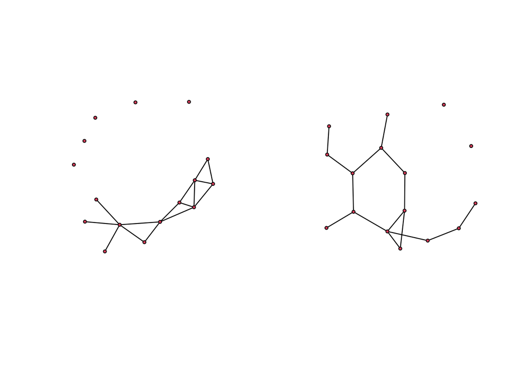

```r
par(mfrow=c(1,2))
plot(padgbus.net)
plot(as.network(cg100[1,,],directed=FALSE ))
```

> Does the random graph look more like the empirical graph?

#### Calculate metrics on random networks

Any metric that we calculate for the *observed* network we can calculate for a *random* network. Calculate density, degree distribution, and triangles for all 100 networks and plot and compare

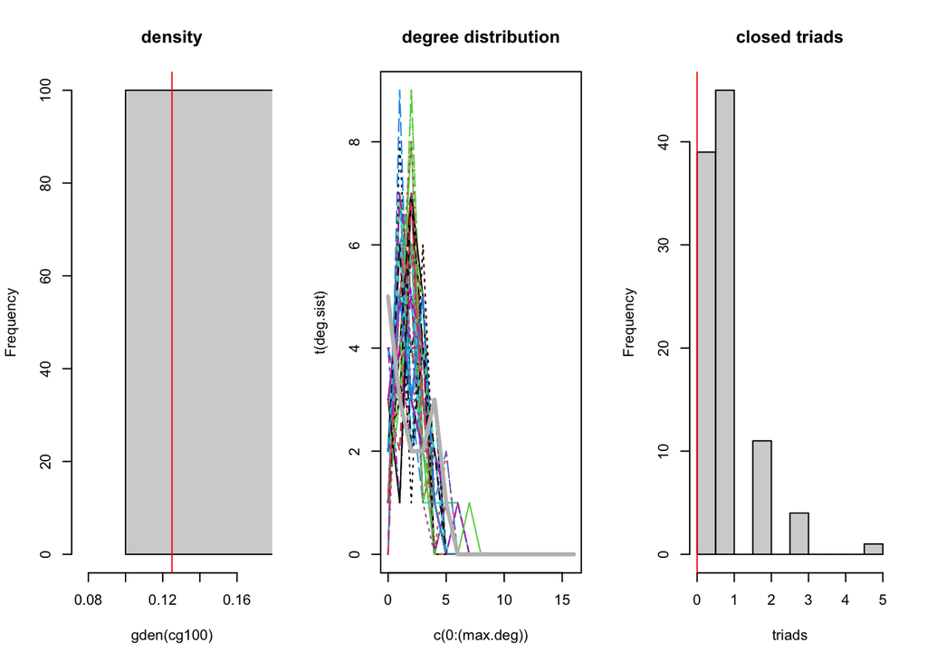

```r
par( mfrow  = c(1,3) )
hist( gden( cg100) , # the density for each of the 100 random networks
      xlim=range( gden( cg100 ),
                  gden( padgbus.net ) ) , main='density')
abline( v=gden( padgbus.net ),col='red' )# the observed density for reference

obs.degrees <-  degree(padgbus.net,cmode='indegree')# obserrved degrees
obs.degree <-  c(sum(obs.degrees==0),tabulate(obs.degrees, nbins=max.deg))# observed degree distribution
degrees <-degree(cg100,g=c(1:100), cmode='indegree')# you can calculate the degree distributions for all graphs
deg.sist <- cbind( matrix( colSums(degrees==0),100,1),
                  t(apply(degrees,2,function(x) tabulate(x, nbins=max.deg) ) ) )# when tabulating we need to add the number of isolates
matplot(c(0:(max.deg)), t(deg.sist) ,
        type ='l',
        main='degree distribution' )
lines(c(0:(max.deg)),obs.degree ,col='grey',lwd=3)
T4 <- triad.census(padgbus.net)[4]# observed number of closed triangles
triads <- triad.census( cg100 , mode='graph' )[,4]
hist(triads ,
     xlim= range( triads , T4),
     main = 'closed triads')
abline( v=T4,col='red' )# the observed density for reference
```

The density is constant but

> The degree distributions have completely different shape to the observed (grey) and few of the simulated networks have many triangles

### Another example

A classic training data set, originally collected by Read (1954), is that of $n=16$ tribes of the Gahuku–Gama alliance structure of the Eastern Central Highlands of New Guinea and their positive and negative ties (Hage and Harary 1983).

```r
tribes.all  <- as.matrix(read.table("https://raw.githubusercontent.com/johankoskinen/CHDH-SNA/main/data/RedHighlandTribes.txt"))
tribesPos <- tribes.all[1:16,]# the first 16 lines are the positive ties
gden(tribesPos)# using sna to calculate density of an adjacency matrix
```

```
## [1] 0.2416667
```

```r
tribesPos.net <- as.network( tribesPos , directed=FALSE)# translate the matrix to a network object
```

#### Simulate graphs

```r
cg100 <- rgnm(n =100,# number of networks to generate
            nv= dim(tribesPos)[1],#size of the network
            m = sum(tribesPos)/2,# number of edges
            mode="graph") # undirected (graph) or directed (digraph)
```

#### Plot random

Plot the observed network and *one* of the simulated networks

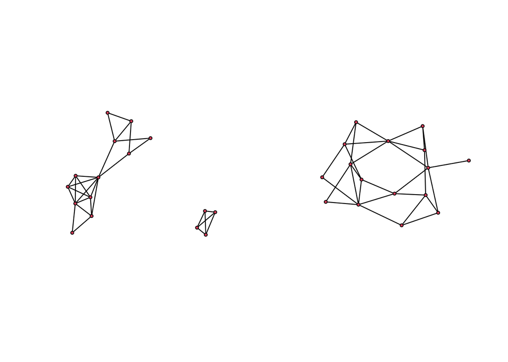

```r
par(mfrow=c(1,2))
plot(as.network( tribesPos , directed=FALSE))
plot(as.network(cg100[1,,],directed=FALSE ))
```

#### Calculate metrics

Calculate density, degree distribution, and triangles for all 100 networks and plot and compare

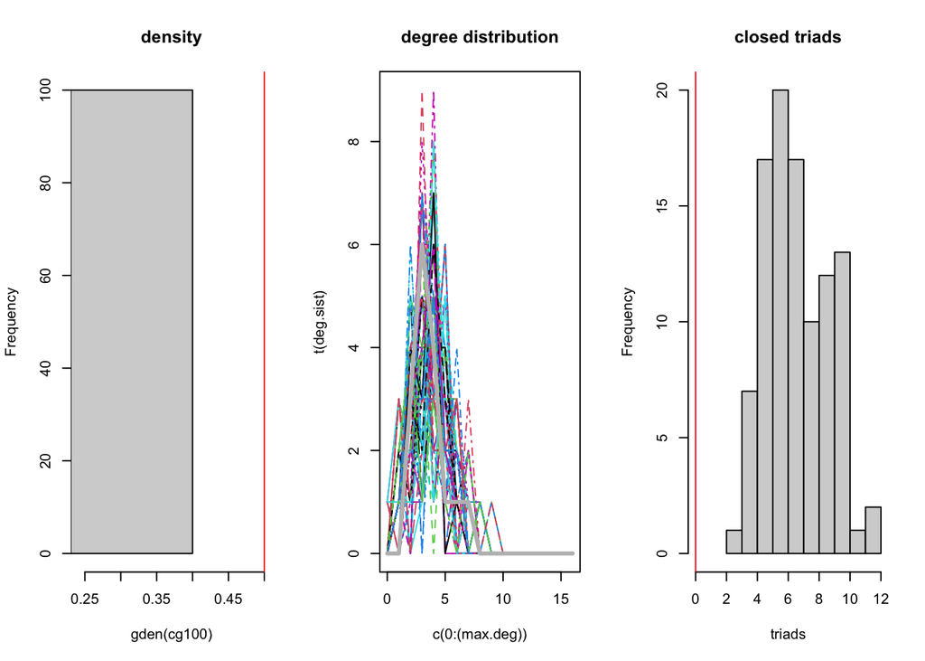

```r
max.deg <- 16
par( mfrow  = c(1,3) )
hist( gden( cg100) , # the density for each of the 100 random networks
      xlim=range( gden( cg100 ),
                  gden( net ) ) , main='density')
abline( v=gden( net ),col='red' )# the observed density for reference

obs.degrees <-  degree(tribesPos.net ,cmode='indegree')# obserrved degrees
obs.degree <-  c(sum(obs.degrees==0),tabulate(obs.degrees, nbins=max.deg))# observed degree distribution
degrees <-degree(cg100,g=c(1:100), cmode='indegree')# you can calculate the degree distributions for all graphs
deg.sist <- cbind( matrix( colSums(degrees==0),100,1),
                  t(apply(degrees,2,function(x) tabulate(x, nbins=max.deg) ) ) )# when tabulating we need to add the number of isolates
matplot(c(0:(max.deg)), t(deg.sist) ,
        type ='l',
        main='degree distribution' )
lines(c(0:(max.deg)),obs.degree ,col='grey',lwd=3)

T4 <- triad.census(tribesPos.net)[4]# observed number of closed triangles
triads <- triad.census( cg100 , mode='graph' )[,4]
hist(triads ,
     xlim= range( triads , T4),
     main = 'closed triads')
abline( v=T4,col='red' )# the observed density for reference
```

## Erdos-Renyi

### Definition

The Bernoulli graph assumes that *independently* for each dyad $\{i,j\} \in \mathcal{N}$, a tie is formed with probability $p_{ij} \in (0,1)$
$$\Pr(X_{ij}=1 ) = p_{ij}$$
It is a *homogenous* Bernoulli graph, or Erdos-Reyni graph, if $p_{ij}=p$ for all $\{i,j\} \in \mathcal{N}$. We say that
$$X \thicksim Bern(p)$$
for a homogenous Bernoulli model with tie-probability $p$.

A particular form of Bernoulli graphs are stochastic blockmodels, where the tie-probability for $\[ i,j \}$ depends on class memberships of the nodes $i$ and $j$.

### Padgett’s business network

> Will introducing more variability produce more triangles and more skewed degree distriubions?

#### Simulate graphs

```r
ber100 <- rgraph(dim(padgettbus)[1],#size of the network
            m=100,# number of networks to generate
            tprob=gden(padgettbus),# tie probability equal to observed density
            mode="graph") # undirected (graph) or directed (digraph)
```

#### Plot random

Plot the observed network and *one* of the simulated networks

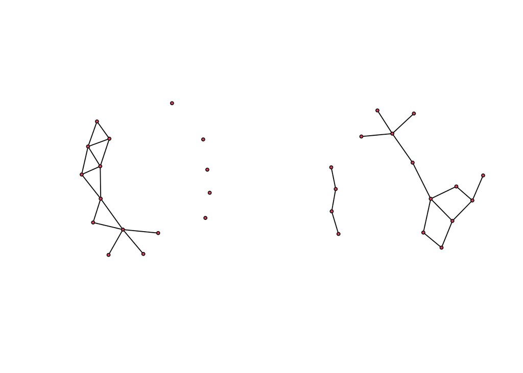

```r
par(mfrow=c(1,2))
plot(padgbus.net)
plot(as.network(ber100[1,,],directed=FALSE ))
```

```r
gden(padgbus.net)# observed density
```

```
## [1] 0.125
```

```r
gden(ber100[1,,])# density of a simulated network
```

```
## [1] 0.1333333
```

> Does the random graph look more like the empirical graph?

#### Calculate metrics on random networks

Any metric that we calculate for the *observed* network we can calculate for a *random* network. Calculate density, degree distribution, and triangles for all 100 networks and plot and compare

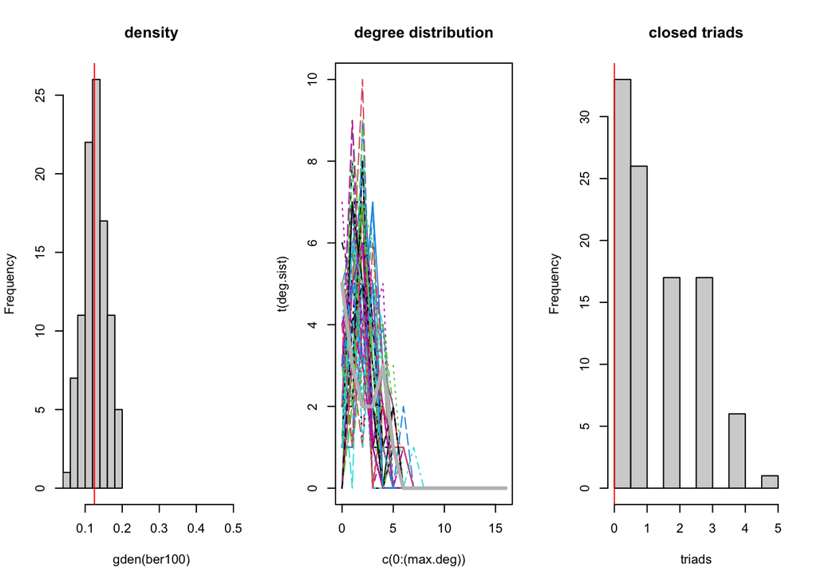

```r
max.deg <- 16
par( mfrow  = c(1,3) )
hist( gden( ber100 ) , # the density for each of the 100 random networks
      xlim=range( gden( ber100 ),
                  gden( net ) ) , main='density')
abline( v=gden( padgbus.net ),col='red' )# the observed density for reference

obs.degrees <-  degree(padgbus.net,cmode='indegree')# obserrved degrees
obs.degree <-  c(sum(obs.degrees==0),tabulate(obs.degrees, nbins=max.deg))# observed degree distribution
degrees <-degree(ber100,g=c(1:100), cmode='indegree')# you can calculate the degree distributions for all graphs
deg.sist <- cbind( matrix( colSums(degrees==0),100,1),
                  t(apply(degrees,2,function(x) tabulate(x, nbins=max.deg) ) ) )# when tabulating we need to add the number of isolates
matplot(c(0:(max.deg)), t(deg.sist) ,
        type ='l',
        main='degree distribution' )
lines(c(0:(max.deg)),obs.degree,col='grey',lwd=3)

T4 <- triad.census(padgbus.net)[4]# observed number of closed triangles
triads <- triad.census( ber100 , mode='graph' )[,4]
hist(triads ,
     xlim= range( triads , T4  ),
     main = 'closed triads')
abline( v=T4 ,col='red' )# the observed density for reference
```

> The degree distributions are more forgiving (but all have wrong shape) but still too few triangles

To get an idea just of how unlikely it is that a Bernoulli graph *could have* produced $5$ triangles (as in Padgett’s data) or more is

```r
mean( triads >= 5 )
```

```
## [1] 0.01
```

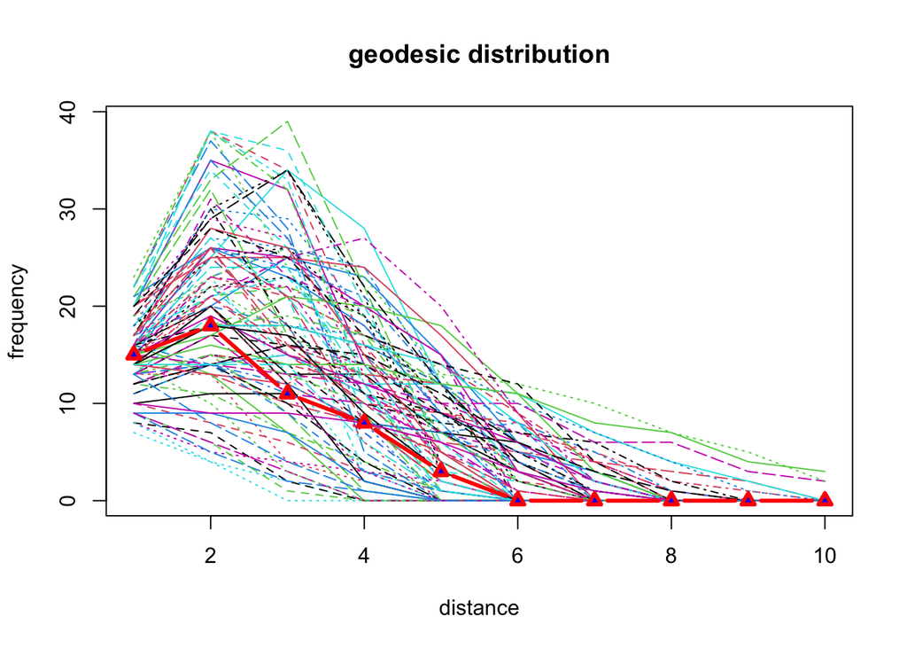

```r
distances <- apply(ber100,
                          1,
                          function(x) tabulate( geodist( x )$gdist[upper.tri(geodist( x )$gdist)] , nbins=10 ) )


matplot(c(1:(10)), distances ,
        type ='l',
        main='geodesic distribution' ,
        xlab='distance',
        ylab='frequency')
lines(c(1:(10)),
      tabulate( geodist( padgbus.net )$gdist[upper.tri(geodist( padgbus.net )$gdist)] , nbins=10 ),
      pch=24,bg="blue",lty=1,type='b',
      col='red',lwd=3 )
```

The model $X \thicksim Bern(p)$ does great in capturing the distances - Bernoulli graphs have **short pathlengths**. It achieves this by sacrifing clustering though. If there is a choice between ‘linking to someone new’ or ‘linking back to someone you indirectly know’, it choses the new one - because ties form idependenlty, the Bernoulli tie-probability does not know whom a node already has ties to.

> Bernoulli graphs do not waste ties on clustering - this creates reach

Interpreting this in terms of tie-formation processes:

> Independence means that a tie is more likely to a ‘new’ person than to ‘a friend of a friend’ because Bernoulli does not know (independence) whom your friends already are

Clearly, we cannot assume that people form ties independently of each other!

### For all graphs

You could try to see how $X \thicksim Bern(p)$ performs for some other networks. In addition to the tribes (Hage and Harary 1983), you could check these ones out

```r
### Padgetts marriage data
# padgettmar  <- as.matrix(read.table("https://raw.githubusercontent.com/johankoskinen/CHDH-SNA/main/data/PADGM.txt"))
```

The extra variability offered by $Bern(p)$ does a little to improve the features of the simulated networks but much of the clustering and centralisation remains unexplained.

## Conditional degree distribution

Since it is clear that $Bern(p)$ does not capture the degree distribution of the typical observed network. This is not surprising given that the tie-probabilities for all dyads is the same and thereby for all nodes - all nodes should have on average the same degree.

To see how much of the structure of a network we can explain through the degree distribution we introduce yet another model.

### Definition

Like the $U \mid L(X)=k$ distribution, we define a distribution for graphs (not for tie-variables). We let $X \thicksim U \mid X_{\cdot+}=d$ mean that the distribution is uniform on all the graphs that have *the exact same degree distribution*. Thus
$$\Pr( X = x) = \left\{
\begin{array}{lr}
c^{-1},&\text{if } x_{\cdot+}=d\\
0,&\text{else}
\end{array}
\right. {\text{,}}$$
where $x_{\cdot+}=(\sum_j x_{1j},\ldots,x_{nj})^{\top}$ is the vector of degrees, and $c = \sharp \{ x \in \mathcal{X}: x_{\cdot+}=d \}$.

There are several algorithms for simulating networks with fixed degree distribution and all of (the reliable ones) rely on Markov chain Monte Carlo (MCMC).

#### Note on MCMC

The premise of MCMC is the you want to draw one variable $x$ from a distribution $p(x)$ but you cannot do that directly. What you can do though is to say how much more likely one realisation of a variable is relative to another. For example, let $x$ and $y$ be two networks and that the *target distribution* is $p(x)$. What we need to know in order to use MCMC is the ratio $p(x)/p(y)$ for all $x,y \in \mathcal{X}$. This allows us to generate a sequence of realisations
$$x_0,x_1,x_2,\ldots,x_K$$
of outcomes. This is an iterative scheme where you have an updating rule that takes an outcome $x_t$ and updates it to $x_{t+1}$, and this update relies on our ability to calculate $p(x)/p(y)$ for all $x,y \in \mathcal{X}$. In particular, if we are in state $x_t$, and we consider moving to state $x^{\ast}$, we know how much more or less likely the new state is relative to the old state $p(x^{*})/p(x_t)$. For networks, these updates are often incremental and you either set $x_{t+1}:=x^{\ast}$ or $x_{t+1}:=x_{t}$, depending on $p(x^{*})/p(x_t)$. Consequently, sometimes we stay in the same state, in the same network, for many iterations.

Burnin: to make sure that $x_t$ has ‘forgotten’ the initial state $x_0$, you usuall allow for a number of interations to pass - this is the burnin period.

Thinning: If you have an adequate burning and want to draw many outcomes, you may not have to do the same burnin again, instead you allow for a certain number of iterations bewtween sucessive sample points - the number of iterations you wait is called thinning.

### Padgett’s business network

#### Simulate graphs

```r
g.udegs <- simulate(padgbus.net~edges,
                    coef=c(0),
                    constraints=~degreedist,# this is what does it degreedist is based on padgbus.net
                    nsim=100,
                    control=control.simulate(MCMC.burnin=100000))# you need to bump up the default burnin, otherwise the networks are too similar to the starting point, the observed network
```

```
## Best valid proposal 'CondDegreeDist' cannot take into account hint(s) 'triadic'.
```

To confirm that this network actually has the same degree distribution:

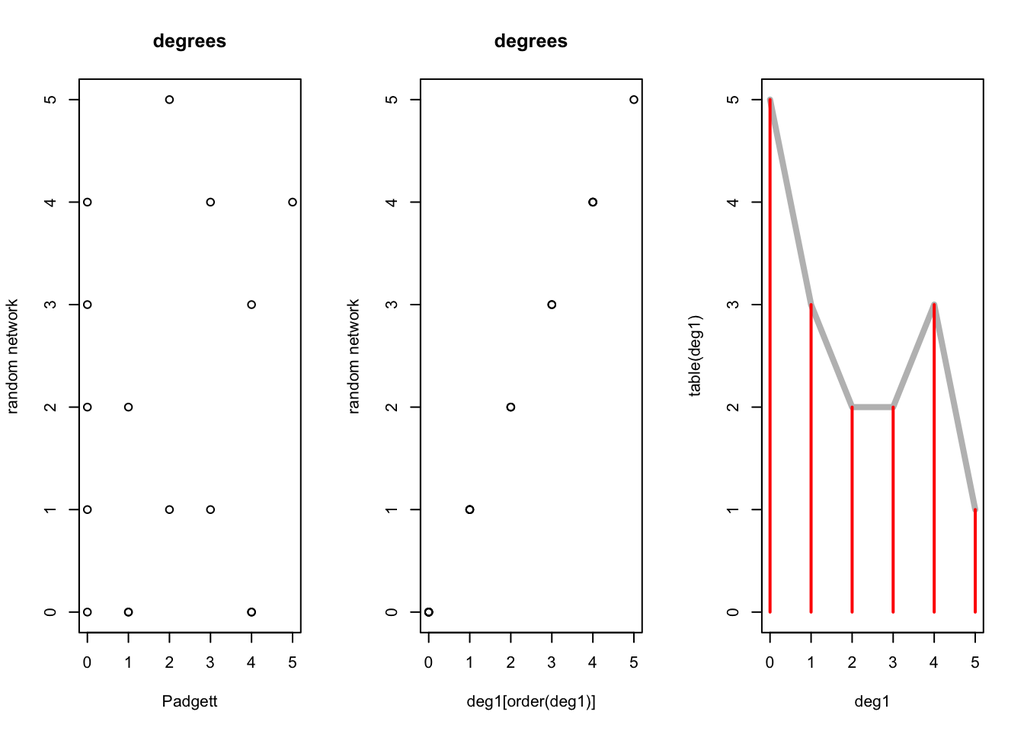

```r
par(mfrow=c(1,3))
deg1 <- degree(padgbus.net, cmode='indegree')
deg2 <- degree(g.udegs[[5]], cmode='indegree')# this is a list of networks, not an array, hence [[k]]
plot( deg1,deg2 ,xlab='Padgett', ylab ='random network',main='degrees')#
plot( deg1[order(deg1)],deg2[order(deg2)] ,ylab ='random network',main='degrees')# the degree distribution is the same but not the same nodes have the same degrees
plot( table(deg1), type='l',col='grey',lwd=4)
lines( table(deg2) ,col='red' )
```

From the first panel we see that not every node has the same degree in the random network as in the observed network. However, the degree distribution is the same, as seen in thee right-hand panel. The middle panel shows that there is a mapping from the nodes in $x_{\mathbf{obs}}$ to the nodes in $x$, so that if for every node with degree $k$ in the former, there is exactly one node in the latter that has degree $k$.

### Plot random

Plot the observed network and then three of the random networks

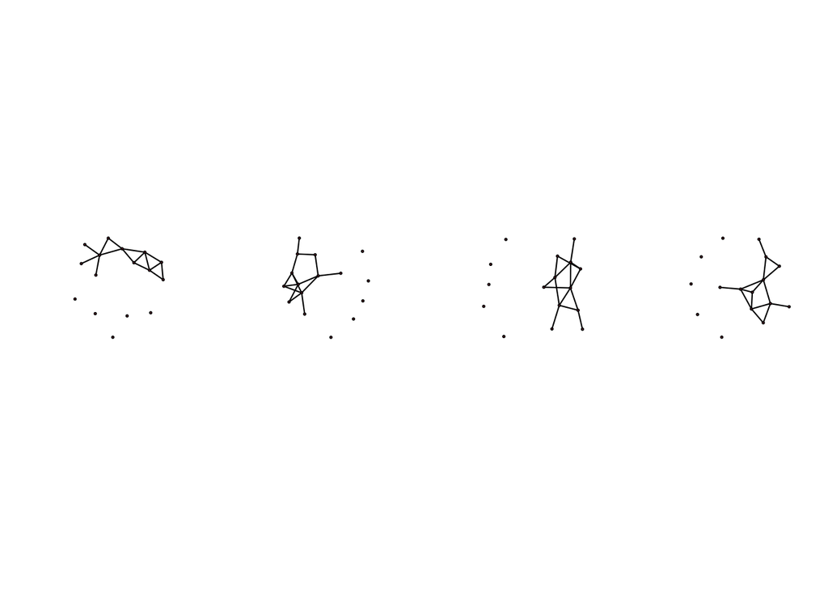

```r
par( mfrow =c(1,4) )
plot( padgbus.net )
plot( g.udegs[[5]] )
plot( g.udegs[[50]] )
plot( g.udegs[[100]] )
```

> The simulated networks look like pretty faithful representations of the observed network

Since the degree distribution is identical to the observed network, the density will also be preserved for all simulated networks. Let us look at triangles and geodesic distances.

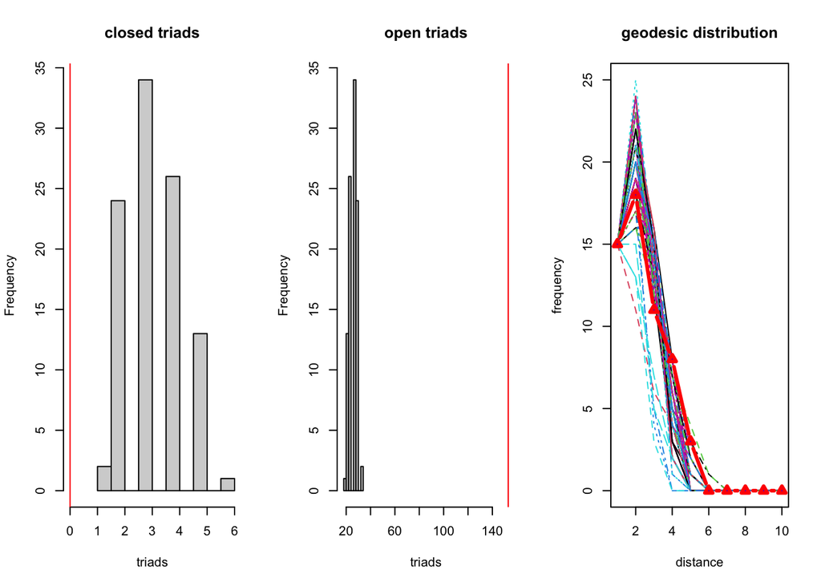

```r
par( mfrow  = c(1,3) )
T4 <- triad.census(padgbus.net)[4]# observed number of closed triangles
triads <- triad.census( g.udegs , mode="graph")[,4]
hist(triads ,
     xlim= range( triads , T4 ),
     main = 'closed triads')
abline( v=T4,col='red' )# the observed density for reference

T3 <- triad.census(padgbus.net)[3]# observed number of closed triangles
triads <- triad.census( g.udegs ,mode="graph" )[,3]
hist(triads ,
     xlim= range( triads , T3 ),
     main = 'open triads')
abline( v=T3,col='red' )# the observed density for reference

# because g.udegs is a list it is a little more complicated to use built in sna functions
distances <- matrix(0,10,100)
for (k in c(1:100))
{
  distances[,k] <- tabulate( geodist( g.udegs[[k]] )$gdist[upper.tri(geodist( g.udegs[[k]] )$gdist)],
                             nbins=10 )
}

matplot(c(1:(10)), distances ,
        type ='l',
        main='geodesic distribution' ,
        xlab='distance',
        ylab='frequency')
lines(c(1:(10)),
      tabulate( geodist( padgbus.net )$gdist[upper.tri(geodist( padgbus.net )$gdist)] , nbins=10 ),
      pch=24,bg="blue",lty=1,type='b',
      col='red',lwd=3 )
```

> Even if we could model the degree of every node exactly, we cannot produce the same clustering that we see for real networks

> The degree distribution alone is not sufficient for explaining clustering and reach - people do not only care about how many friends they have

## ERGM

### Definition

An introduction to ERGMs is given in the slides. Formally, an ERGM is a model
$$\Pr( X = x \mid \theta) = \frac{ \exp \{ \theta^{\top}z(x) \} }{
\sum_{x \in \mathcal{X} } \exp \{ \theta^{\top}z(x) \} }$$

where * $\theta$ is a vector of statitical parameters * $z(x)$ is a vector of statistics calculated on $x$ * the denominator is a sum over all graphs ensuring that the probaility sums to one

#### Example

If $z(x)=L(x)$, the only model statistic is the number of edges in the graph. This model is equivalent to $Bern(p)$, where
$$\theta = - \log\left( \frac{1}{p-1}\right)$$
or, expressed in terms of $p$
$$p= \frac{e^{\theta L(x)}}{1+e^{\theta L(x)}}$$

### Properties

A property of ERGM is that you can set the values of the expected statistics. The expected statistics
$$E_{\theta} \{ z(X) \} = \sum_{x \in \mathcal{x}} z(x)\Pr( X = x \mid
\theta)$$
are completely determined by the parameters.

### Padgett’s business network

#### Bernoulli model

Simulate networks from an ERGM with only the statistic $z(x)=L(x)$ and paramter $\theta = −1.945$

```r
g.ergm.bern <- simulate(padgbus.net~edges,# one statistic
                    coef= -1.945,# one parameter
                    nsim=100,
                    control=control.simulate(MCMC.burnin=100000))# you need to bump up the default burnin, otherwise the networks are too similar to the starting point, the observed network
```

Inspect networks

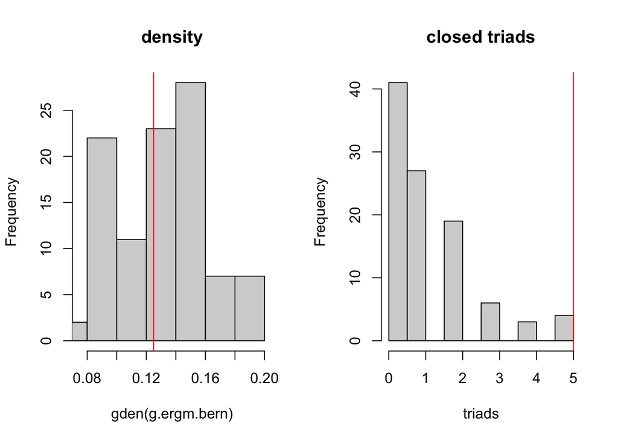

```r
par( mfrow  = c(1,2) )
hist( gden( g.ergm.bern ) , # the density for each of the 100 random networks
      xlim=range( gden( g.ergm.bern ),
                  gden( padgbus.net ) ) , main='density')
abline( v=gden( padgbus.net ),col='red' )# the observed density for reference


triads <- triad.census( g.ergm.bern , mode='graph' )[,4]
hist(triads ,
     xlim= range( triads , triad.census( padgbus.net , mode='graph' )[,4] ),
     main = 'closed triads')
abline( v= triad.census( padgbus.net , mode='graph' )[,4],col='red' )# the observed density for reference
```

The denisty of graphs is centred right over the observed value! Because this model is equivalent to $Bern(p)$, the missfit of closed triads is the same as before.

> The Bernoulli ERGM assumes that ties form independently - how can we relax that?

#### Markov model

Since the Bernoulli ERGM does not reproduce the number of triangles, how do can we improve on that?

If we add statistics for the number of triangles we can increase the number of triangles that the model produces. Let us add statistics:

- edges: $\sum_{ i <j }x_{ij}$
- two-stars: $\sum_{ i ,j,k }x_{ij}x_{ik}$
- three-stars: $\sum_{ i ,j,k,h }x_{ij}x_{ik}x_{ih}$
- triangles: $\sum_{ i ,j,k}x_{ij}x_{ik}x_{jk}$

```r
g.ergm.markov <- simulate(padgbus.net~edges+kstar(2) +kstar(3) + triangles,# one statistic
                    coef= c(-4.4878  ,  1.2556 ,  -0.7059  ,  1.0266),# one parameter
                    nsim=100,
                    control=control.simulate(MCMC.burnin=100000))# you need to bump up the default burnin, otherwise the networks are too similar to the starting point, the observed network
```

Inspect networks

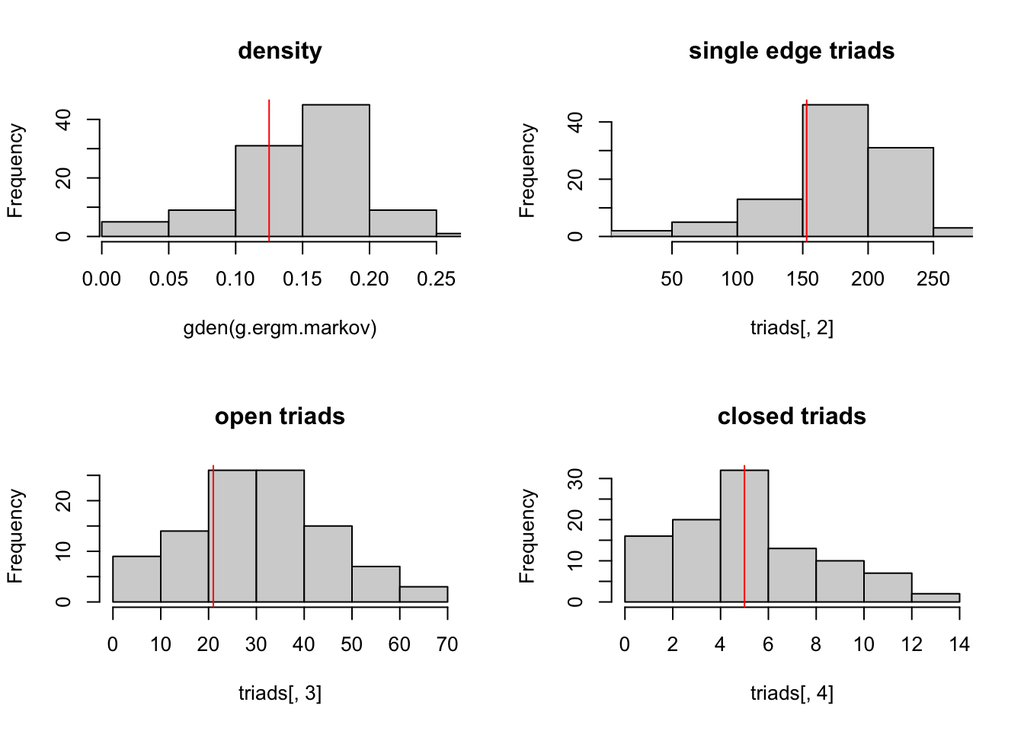

```r
par( mfrow  = c(2,2) )
hist( gden( g.ergm.markov ) , # the density for each of the 100 random networks
      xlim=range( gden( g.ergm.markov ),
                  gden( padgbus.net ) ) , main='density')
abline( v=gden( padgbus.net ),col='red' )# the observed density for reference


triads <- triad.census( g.ergm.markov , mode='graph' )
obsetriad <- triad.census(padgbus.net, mode='graph' )

hist(triads[,2] ,
     xlim= range( triads[,2] , obsetriad[2] ),
     main = 'single edge triads')
abline( v= obsetriad[2],col='red' )# the observed density for reference

hist(triads[,3] ,
     xlim= range( triads[,3] , obsetriad[3] ),
     main = 'open triads')
abline( v= obsetriad[3],col='red' )# the observed density for reference

hist(triads[,4] ,
     xlim= range( triads[,4] , obsetriad[4] ),
     main = 'closed triads')
abline( v= obsetriad[4],col='red' )# the observed density for reference
```

> The Markov model manages to reproduce all of these local, structural statistics

Let us look at a global property, like geodesic distances

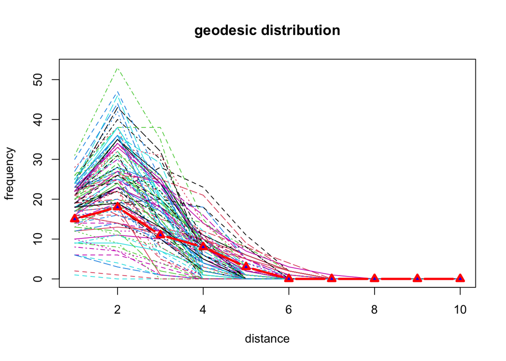

```r
# because g.udegs is a list it is a little more complicated to use built in sna functions
distances <- matrix(0,10,100)
for (k in c(1:100))
{
  distances[,k] <- tabulate( geodist( g.ergm.markov[[k]] )$gdist[upper.tri(geodist( g.ergm.markov[[k]] )$gdist)],
                             nbins=10 )
}

matplot(c(1:(10)), distances ,
        type ='l',
        main='geodesic distribution' ,
        xlab='distance',
        ylab='frequency')
lines(c(1:(10)),
      tabulate( geodist( padgbus.net )$gdist[upper.tri(geodist( padgbus.net )$gdist)] , nbins=10 ),
      pch=24,bg="blue",lty=1,type='b',
      col='red',lwd=3 )
```

The Markov model does a pretty spectacular work of also capturing the reach in the network

> The Markov model with 4 paramters is sufficient to explain density, local clustering, as well as connectivity

We can interpret this as the degree-based effects - the edges and stars - cature mechanisms to do with popularity and activity; and, the triangle parameter captures triadic closure - friends of my friends are also my friends. There are many behvioural interpretations of these mechanisms but at the end of the day they are sufficient for explaining a lot of the network structure.

### Kapferer’s tailors

Let us try an ERGM for Kapferer’s tailors.

Kapferer (1972) studied a group of tailors in Zambia and collected a number of networks for the $n=39$ individuals.

```r
kapf  <- as.matrix(read.table("https://raw.githubusercontent.com/johankoskinen/CHDH-SNA/main/data/kapferer.txt"))
# "sociational" (friendship, socioemotional) interactions.
KAPFTS1 <- kapf[1:39,]#KAPFTS1 symmetric, binary: time 1
KAPFTS1.net <- as.network( KAPFTS1 ,directed=FALSE)
```

This time, we use the statistics edges and so-called alternating triangles. Alternating triangles, or GWESP, counts the number of shared partners that two directly tied individuals have. Each additional shared partner adds to the statistic but with a geometrically decreasing weight.

```r
g.ergm.gwesp <- simulate(KAPFTS1.net~edges+gwesp(decay = log(2) , fixed= TRUE),# one statistic
                    coef= c(-3.795, 1.075),# the two parameters
                    nsim=100,
                    control=control.simulate(MCMC.burnin=100000))# you need to bump up the default burnin, otherwise the networks are too similar to the starting point, the observed network
```

Inspect networks

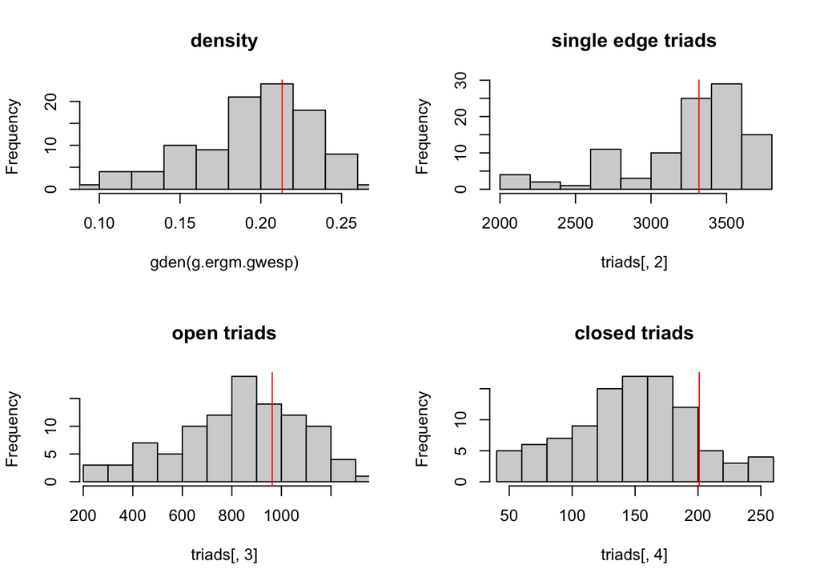

```r
par( mfrow  = c(2,2) )
hist( gden( g.ergm.gwesp ) , # the density for each of the 100 random networks
      xlim=range( gden( g.ergm.gwesp ),
                  gden( KAPFTS1.net ) ) , main='density')
abline( v=gden( KAPFTS1.net ),col='red' )# the observed density for reference


triads <- triad.census( g.ergm.gwesp , mode='graph' )
obsetriad <- triad.census(KAPFTS1.net, mode='graph' )

hist(triads[,2] ,
     xlim= range( triads[,2] , obsetriad[2] ),
     main = 'single edge triads')
abline( v= obsetriad[2],col='red' )# the observed density for reference

hist(triads[,3] ,
     xlim= range( triads[,3] , obsetriad[3] ),
     main = 'open triads')
abline( v= obsetriad[3],col='red' )# the observed density for reference

hist(triads[,4] ,
     xlim= range( triads[,4] , obsetriad[4] ),
     main = 'closed triads')
abline( v= obsetriad[4],col='red' )# the observed density for reference
```

This two-paramter model seem to capture the local clustering well.

> An overall cost for ties (edges) and a tendency for people that have shared friends to also be friends explains most of the network strucure.

## Conclusions

Based on these experiments:

- Assuming that ties form independely is unrealistic
- Independent tie-formation may create short pathways
- Independence means that ** The rich do not get richer (nodes do not know how many ties they already have) ** Closure does not happen (ties have ‘no memory’)
- The degree distribution only explain some network features ** Knowing what nodes are popular do not explain whom they form ties to

### Homework

Explore what other features the random graphs may or may not model

Pick a network, pick some ERGM terms by reference to ergm.terms (use the help function ?ergm.terms).

Try to estimate a model and then simulate from it. How did I get my parameter values? For Padgett is got the coefficients:

```r
# don't run
ans <- ergm(padgbus.net~edges+kstar(2) +kstar(3) + triangles)#
summary(ans)# this produces an ANOVA table with coefficients
```

And for Kapferer:

```r
# don't run
ans <- ergm(KAPFTS1.net~edges+gwesp(decay = log(2) , fixed= TRUE))#
summary(ans)# this produces an ANOVA table with coefficients
```

> Can you pick any statistic arbitrarily to include in the model?

There are at least three reasons the answer to this is no:

- Higher order effects, like triangles, may be explained by the aggregation of lower-order statistics (such as two-stars)
- Even if you want to model one specific statistic, it is not certain that you will be able to (see homework)
- The Markov model and a model with GWESP can be represented in terms of principled dependence assumptions and other statistics do not have that interpretation

# Ego-nets

For standard surveys, respondents are sampled independently of each other and we do not get any network data. The one piece of network information we can get from a surevey is the number of contacts a respondent has - this is the **degree** of the respondent.

> How much can we say about a network and a persons network position based only on independent reports?

Survey data may provide *egocentric*, as opposed to *socio-centric*, network data. We call this **egonetworks** (Crossley et al. 2015).

In the US General Social Survey, respondents have been asked to nominate a range of different contacts. Here, we will

- investigate the degree distributions of different relations,
- examine to what extent we can explain the *degree centrality* using independent variables, and
- examine the extent to which the *degree centrality* can explain other outcomes

The last sections (Fitting a distribution and Measurement error) provide brief introductions to more advanced topics.

## Loading data

We are going to read in a stata file and for that we need the package

```r
library('foreign')
library('haven')# this package is needed to read Stata version 5-12 .dta file
library('labelled')# this is needed to undo all the annoying things haven does
```

Download the General Social Survey data from the web first time around. Going forward you may want to save it locally. You can download data from https://gssdataexplorer.norc.org/ and read in the downloaded dataset (also the GSS for 1985) but here we will read the data straight from the url:

```r
#GSSdata <- read.dta( 'https://osf.io/hn5b9/download' , convert.factors=FALSE )
GSSdata <- as.data.frame( read_dta( 'https://osf.io/npjv3/download' ), stringsAsFactors=FALSE )
val_labels(GSSdata) <- NULL
```

For `r'read.dta'`, by setting convert.factors=FALSE we are using numerical codes for categorical variables

## Data matrix

The dataset is a

```r
class(GSSdata)
```

```
## [1] "data.frame"
```

with dimensions

```r
dim(GSSdata)
```

```
## [1] 2812 1180
```

#### Basic demographic variables

Basic variables include

| Number in list | variable name | name in GSSdata | description |
| --- | --- | --- | --- |
| (3) | WRKSTAT | wrkstat | employment status |
| (12) | MARITAL | marital | marital status |
| (24) | PAOCC80 | PAOCC80 | father’s and mothers occupation |
| (27) | MAOCC80 | MAOCC80 | mothers occupation |
| (39) | DEGREE | degree | education |
| (43) | SEX | sex | sex of respondent |
| (33) | AGE | age | age of respondent |

There are many measures of attritudes, for example political views (73 POLVIEW), towards government spending (74-101), race, racism, and ethnicity, religion etc. In general there are also a lot of questions about third parties, such as the household and household members. Many questions consists of a long battery of targeted attitudes, such as ‘confidence’ in questions (163-176).

#### Psychological wellbeing

There are a variety of Psychological wellbeing measures

| Number in list | variable name | name in GSSdata | description |
| --- | --- | --- | --- |
| (157) | HAPPY | happy | A happiness measure |
| (160) | LIFE | life | Excitement with Life |
| (459) | MNTLHLTH | mntlhlth | self-assesed (negative) mental health |
| (960) | HLTH2 | HLTH2 | If underwent counseling for mental or emotional problems |

#### Scales, subscales, and single items

While there is no specific documentation or listing of scales used in the survey, we recognise a number of questions as items from other scales.

[output not shown]

It is worth looking through http://www.thearda.com/Archive/Files/Codebooks/GSS2004_CB.asp searching for terms of interest.

### Network summaries

The 2004 (and some earlier surveys) contain a number of network and network-related variables.

| Variable name | Description | Note |
| --- | --- | --- |
| partners | no. sex partners past year | listed as PARTNERS in help file. Vars 931-938 further breakdowns |
| numwomen | no. female sex partners | listed as NUWOMEN in help file |
| nummen | no. male sex partners | listed as NUMMEN in help file |
| PARTNRS5 | no. sex partners in past 5 years | binned |
| numgiven | no. close contacts | truncated at 6+. |
| numcnt | no. people keep in contact with | this is other than family and work |
| 434-437 | mode of contact | keeping in contact with f-t-f, letters, email, etc |

These are summaries of a (population) sexual network and a (population) close contact network (a number of related network questions address different aspect of social interaction).

Note: The variable HAPPY, the Trust (161 - 162) and EC (462-468) scales, are not asked of people that provided ‘numgiven’. Therefore it is important to check cross tabulations before doing an analysis, for example, tabulating happy against numgiven demonstrates that there are no respondents with values on both.

```r
table(GSSdata$happy,GSSdata$numgiven,useNA='always')
```

There were 6 versions of the survey administered and not all of them included all questions, for example

```r
table(GSSdata$version,GSSdata$happy, useNA='always')
table(GSSdata$version,GSSdata$numgiven, useNA='always')
```

## Number of sex partners

The networks of sexual contacts has received a lot of attention in public health, see for example Morris (2004). The number of sexual contacts also serves as a good illustration for modelling the degree distribution of a network from survey data.

The number of sex partners is partially reported as binned and the missing data code is 99

```r
sexpart <- GSSdata$partners
sexpart[sexpart %in% c(9,989,99)] <- NA # missing data codes
sexpart[sexpart == 5 ] <- 7.5 # middle of range (4,10]
sexpart[sexpart == 6 ] <- 15 # middle of range (10,20]
sexpart[sexpart == 7 ] <- 60.5  # middle of range (20,100]
sexpart[sexpart == 8 ] <- 100 # 100+
```

The distribution is now

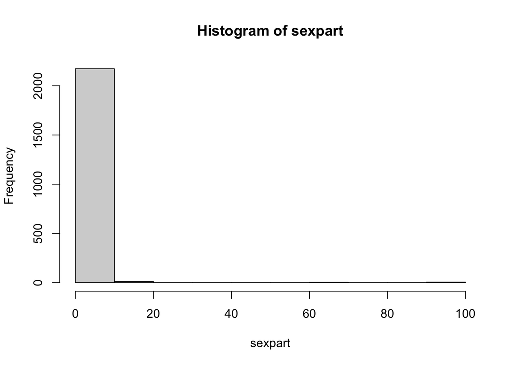

```r
hist(sexpart)
```

And we can look at difference between male and female

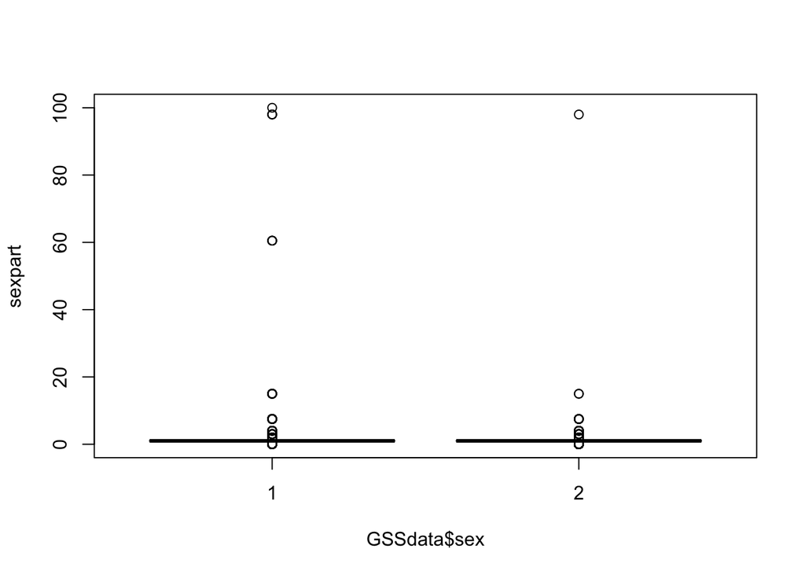

```r
boxplot(sexpart~ GSSdata$sex)
```

However, testing the difference in number of sex partners between men an women, there is a clear difference

```r
sexreg <- lm(sexpart~ GSSdata$sex==1)
summary(sexreg)
```

```
##
## Call:
## lm(formula = sexpart ~ GSSdata$sex == 1)
##
## Residuals:
##    Min     1Q Median     3Q    Max
## -1.989 -0.989 -0.083 -0.083 98.011
##
## Coefficients:
##                      Estimate Std. Error t value Pr(>|t|)
## (Intercept)            1.0831     0.1589   6.814 1.22e-11 ***
## GSSdata$sex == 1TRUE   0.9055     0.2344   3.863 0.000115 ***
## ---
## Signif. codes:  0 '***' 0.001 '**' 0.01 '*' 0.05 '.' 0.1 ' ' 1
##
## Residual standard error: 5.472 on 2192 degrees of freedom
##   (618 observations deleted due to missingness)
## Multiple R-squared:  0.006763,   Adjusted R-squared:  0.00631
## F-statistic: 14.92 on 1 and 2192 DF,  p-value: 0.0001151
```

An equivalent way of testing this difference is by doing a t-test

```r
t.test( sexpart~ GSSdata$sex==1, var.equal = TRUE)
```

```
##
##  Two Sample t-test
##
## data:  sexpart by GSSdata$sex == 1
## t = -3.8633, df = 2192, p-value = 0.0001151
## alternative hypothesis: true difference in means between group FALSE and group TRUE is not equal to 0
## 95 percent confidence interval:
##  -1.3651153 -0.4458451
## sample estimates:
## mean in group FALSE  mean in group TRUE
##            1.083122            1.988603
```

Note that the t-statistics are identical for the regression coefficient and in the t-test.

> If these are the degree distributions in an undirected network, how come that there are such differences? (see also Spiegelhalter 2015).

Because of this discrepancy and the binning we will focus solely on the number of sexual partners of men in the sequel.

## Modelling partners

We are going to define $Y_i$ as the number of sex partners of a *male* $i$.

> The variables $Y_i$ are the out-degrees of men in the network of sexual partners

We will model $Y_i$ using

- Linear regression
- Log-linear regression
- Poisson regression
- A power-law

Recode missing values for number of female sex partners and for the variable pre-marital sex

```r
numwom <- GSSdata$nuwomen
numwom[numwom  > 993 ] <- NA # missing data codes
is.man <- GSSdata$sex==1
premarsx <- GSSdata$premarsx
premarsx[premarsx > 4] <- NA
```

### OLS

We assume
$$Y_i = \beta_0 + \beta_1 x_{i} +\epsilon_i$$
for $x_{i}$ being attitude to pre-marital sex and $\epsilon_i \overset{i.i.d}{\thicksim}N(0,\sigma^2)$.

The OLS estimates are given by

```r
y <- numwom[ is.man ]# this for plotting reasons below
x <- premarsx[is.man ]# ditto
not.use <- is.na(y) | is.na(x)
y <- y[not.use==FALSE]
x <- x[not.use==FALSE]
nuwom.reg <- lm( y ~ x)
summary( nuwom.reg )
```

```
##
## Call:
## lm(formula = y ~ x)
##
## Residuals:
##    Min     1Q Median     3Q    Max
## -47.21 -37.21 -22.21  -5.63 956.31
##
## Coefficients:
##             Estimate Std. Error t value Pr(>|t|)
## (Intercept)   -2.901     18.242  -0.159   0.8737
## x             12.529      5.548   2.258   0.0246 *
## ---
## Signif. codes:  0 '***' 0.001 '**' 0.01 '*' 0.05 '.' 0.1 ' ' 1
##
## Residual standard error: 121.6 on 337 degrees of freedom
## Multiple R-squared:  0.01491,    Adjusted R-squared:  0.01198
## F-statistic:   5.1 on 1 and 337 DF,  p-value: 0.02457
```

Check the residuals to see if the normality assumption appears satisfied

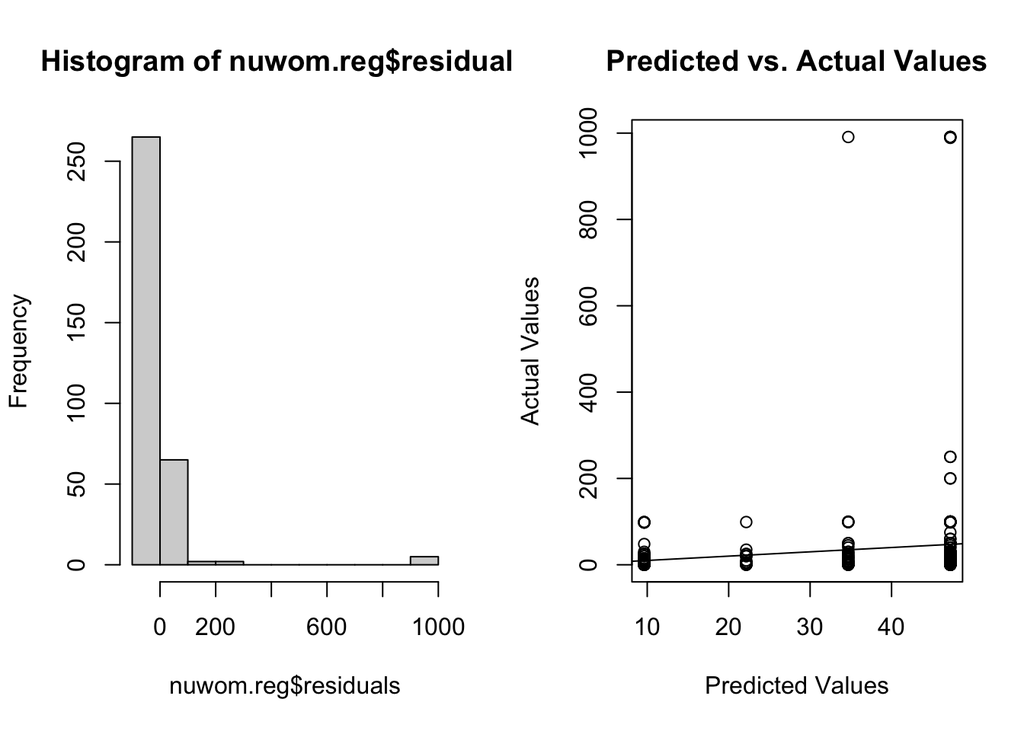

```r
par(mfrow=c(1,2))
hist(nuwom.reg$residuals)
plot(x=predict(nuwom.reg), y= y,
     xlab='Predicted Values',
     ylab='Actual Values',
     main='Predicted vs. Actual Values')
abline(a=0, b=1)
```

### Log-normal

While the residuals are very skewed (and *not* normal), the logarithm of the residuals might look different (we would have to do some transformation as we cannot take the log of non-positive values).

Outcome variable needs to be strictly positive

```r
is.pos <- y>0
```

Letting $Z_i=\log(Y_i)$, we estimate
$$Z_i = \alpha +\gamma X_{i} +\xi_i$$

```r
log.nuwom.reg <- lm( log(y[is.pos]) ~ x[is.pos])
summary(log.nuwom.reg)
```

```
##
## Call:
## lm(formula = log(y[is.pos]) ~ x[is.pos])
##
## Residuals:
##     Min      1Q  Median      3Q     Max
## -2.4972 -1.3986 -0.1946  1.0435  4.7534
##
## Coefficients:
##             Estimate Std. Error t value Pr(>|t|)
## (Intercept)  1.08942    0.24140   4.513 9.04e-06 ***
## x[is.pos]    0.35195    0.07288   4.829 2.14e-06 ***
## ---
## Signif. codes:  0 '***' 0.001 '**' 0.01 '*' 0.05 '.' 0.1 ' ' 1
##
## Residual standard error: 1.522 on 315 degrees of freedom
## Multiple R-squared:  0.06894,    Adjusted R-squared:  0.06598
## F-statistic: 23.32 on 1 and 315 DF,  p-value: 2.141e-06
```

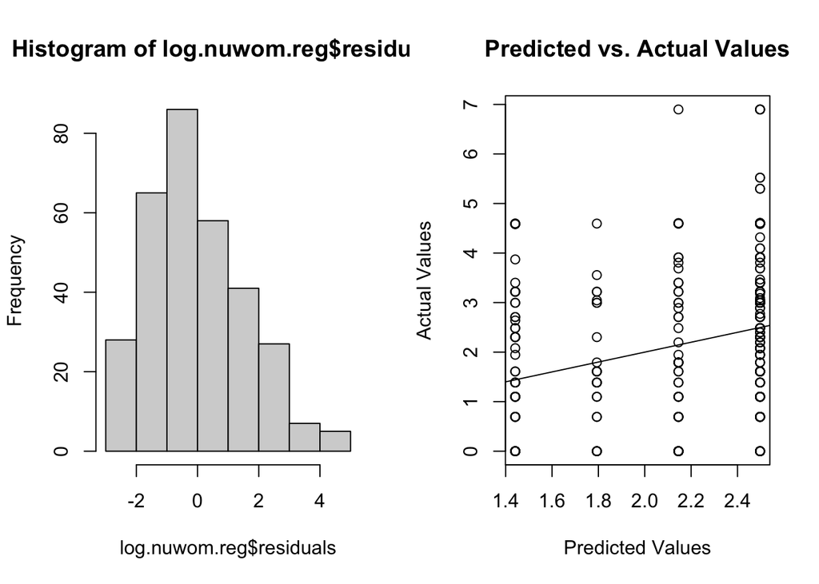

```r
par(mfrow=c(1,2))
hist(log.nuwom.reg$residuals)
plot(x=predict(log.nuwom.reg), y= log(y[is.pos]),
     xlab='Predicted Values',
     ylab='Actual Values',
     main='Predicted vs. Actual Values')
abline(a=0, b=1)
```

## Poisson regression

The orginal degrees $Y_i$ are clearly **counts** and the Poisson distribution may be a better model for counts
$$E(Y_i \mid x_i ) = \lambda_i,\;\Pr(Y_i=h\mid
x_i)=e^{-\lambda_i}\frac{\lambda_i^h}{h!},{\text{ and
}}\log(\lambda_i)=\eta_i=\beta_0+\beta_1x_i$$

We estimate $\beta_0$ and $\beta_1$ using `r'glm'`

```r
reg.po <- glm( y ~ x, family = poisson(link='log') )
summary( reg.po )
```

```
##
## Call:
## glm(formula = y ~ x, family = poisson(link = "log"))
##
## Coefficients:
##             Estimate Std. Error z value Pr(>|z|)
## (Intercept)  2.00319    0.03905    51.3   <2e-16 ***
## x            0.46863    0.01065    44.0   <2e-16 ***
## ---
## Signif. codes:  0 '***' 0.001 '**' 0.01 '*' 0.05 '.' 0.1 ' ' 1
##
## (Dispersion parameter for poisson family taken to be 1)
##
##     Null deviance: 38576  on 338  degrees of freedom
## Residual deviance: 36062  on 337  degrees of freedom
## AIC: 37354
##
## Number of Fisher Scoring iterations: 7
```